# TELECOM_CHURN

## Problem Statement - Given various features about a customer like Gender, SeniorCitizen, Partner, Dependents etc.. , predict if the customer will churn or not.

```python
import pandas as pd
import numpy as np
import matplotlib.pyplot as plt
import seaborn as sns
```

## Step - 1: Load the data

```python
df =  pd.read_csv(r"churn_dataset.csv")
df
```

|  | customerID | gender | SeniorCitizen | Partner | Dependents | tenure | PhoneService | MultipleLines | InternetService | OnlineSecurity | ... | DeviceProtection | TechSupport | StreamingTV | StreamingMovies | Contract | PaperlessBilling | PaymentMethod | MonthlyCharges | TotalCharges | Churn |
| --- | --- | --- | --- | --- | --- | --- | --- | --- | --- | --- | --- | --- | --- | --- | --- | --- | --- | --- | --- | --- | --- |
| 0 | 7590-VHVEG | Female | 0 | Yes | No | 1 | No | No phone service | DSL | No | ... | No | No | No | No | Month-to-month | Yes | Electronic check | 29.85 | 29.85 | No |
| 1 | 5575-GNVDE | Male | 0 | No | No | 34 | Yes | No | DSL | Yes | ... | Yes | No | No | No | One year | No | Mailed check | 56.95 | 1889.5 | No |
| 2 | 3668-QPYBK | Male | 0 | No | No | 2 | Yes | No | DSL | Yes | ... | No | No | No | No | Month-to-month | Yes | Mailed check | 53.85 | 108.15 | Yes |
| 3 | 7795-CFOCW | Male | 0 | No | No | 45 | No | No phone service | DSL | Yes | ... | Yes | Yes | No | No | One year | No | Bank transfer (automatic) | 42.30 | 1840.75 | No |
| 4 | 9237-HQITU | Female | 0 | No | No | 2 | Yes | No | Fiber optic | No | ... | No | No | No | No | Month-to-month | Yes | Electronic check | 70.70 | 151.65 | Yes |
| ... | ... | ... | ... | ... | ... | ... | ... | ... | ... | ... | ... | ... | ... | ... | ... | ... | ... | ... | ... | ... | ... |
| 7038 | 6840-RESVB | Male | 0 | Yes | Yes | 24 | Yes | Yes | DSL | Yes | ... | Yes | Yes | Yes | Yes | One year | Yes | Mailed check | 84.80 | 1990.5 | No |
| 7039 | 2234-XADUH | Female | 0 | Yes | Yes | 72 | Yes | Yes | Fiber optic | No | ... | Yes | No | Yes | Yes | One year | Yes | Credit card (automatic) | 103.20 | 7362.9 | No |
| 7040 | 4801-JZAZL | Female | 0 | Yes | Yes | 11 | No | No phone service | DSL | Yes | ... | No | No | No | No | Month-to-month | Yes | Electronic check | 29.60 | 346.45 | No |
| 7041 | 8361-LTMKD | Male | 1 | Yes | No | 4 | Yes | Yes | Fiber optic | No | ... | No | No | No | No | Month-to-month | Yes | Mailed check | 74.40 | 306.6 | Yes |
| 7042 | 3186-AJIEK | Male | 0 | No | No | 66 | Yes | No | Fiber optic | Yes | ... | Yes | Yes | Yes | Yes | Two year | Yes | Bank transfer (automatic) | 105.65 | 6844.5 | No |

7043 rows × 21 columns

```python
df.info()
```

```
<class 'pandas.core.frame.DataFrame'>
RangeIndex: 7043 entries, 0 to 7042
Data columns (total 21 columns):
 #   Column            Non-Null Count  Dtype
---  ------            --------------  -----
 0   customerID        7043 non-null   object
 1   gender            7043 non-null   object
 2   SeniorCitizen     7043 non-null   int64
 3   Partner           7043 non-null   object
 4   Dependents        7043 non-null   object
 5   tenure            7043 non-null   int64
 6   PhoneService      7043 non-null   object
 7   MultipleLines     7043 non-null   object
 8   InternetService   7043 non-null   object
 9   OnlineSecurity    7043 non-null   object
 10  OnlineBackup      7043 non-null   object
 11  DeviceProtection  7043 non-null   object
 12  TechSupport       7043 non-null   object
 13  StreamingTV       7043 non-null   object
 14  StreamingMovies   7043 non-null   object
 15  Contract          7043 non-null   object
 16  PaperlessBilling  7043 non-null   object
 17  PaymentMethod     7043 non-null   object
 18  MonthlyCharges    7043 non-null   float64
 19  TotalCharges      7043 non-null   object
 20  Churn             7043 non-null   object
dtypes: float64(1), int64(2), object(18)
memory usage: 1.1+ MB
```

```python
df.columns
```

```
Index(['customerID', 'gender', 'SeniorCitizen', 'Partner', 'Dependents',
       'tenure', 'PhoneService', 'MultipleLines', 'InternetService',
       'OnlineSecurity', 'OnlineBackup', 'DeviceProtection', 'TechSupport',
       'StreamingTV', 'StreamingMovies', 'Contract', 'PaperlessBilling',
       'PaymentMethod', 'MonthlyCharges', 'TotalCharges', 'Churn'],
      dtype='object')
```

```python
print(df["gender"].value_counts())
print(df["SeniorCitizen"].value_counts())
print(df["Partner"].value_counts())
print(df["Dependents"].value_counts())
print(df["tenure"].value_counts())
print(df["PhoneService"].value_counts())
print(df["MultipleLines"].value_counts())
print(df["InternetService"].value_counts())
print(df["OnlineSecurity"].value_counts())
print(df["OnlineBackup"].value_counts())
print(df["DeviceProtection"].value_counts())
print(df["TechSupport"].value_counts())
print(df["StreamingTV"].value_counts())
print(df["StreamingMovies"].value_counts())
print(df["Contract"].value_counts())
print(df["PaperlessBilling"].value_counts())
print(df["PaymentMethod"].value_counts())
print(df["MonthlyCharges"].value_counts())
print(df["TotalCharges"].value_counts())
print(df["Churn"].value_counts())
```

```
gender
Male      3555
Female    3488
Name: count, dtype: int64
SeniorCitizen
0    5901
1    1142
Name: count, dtype: int64
Partner
No     3641
Yes    3402
Name: count, dtype: int64
Dependents
No     4933
Yes    2110
Name: count, dtype: int64
tenure
1     613
72    362
2     238
3     200
4     176
     ...
28     57
39     56
44     51
36     50
0      11
Name: count, Length: 73, dtype: int64
PhoneService
Yes    6361
No      682
Name: count, dtype: int64
MultipleLines
No                  3390
Yes                 2971
No phone service     682
Name: count, dtype: int64
InternetService
Fiber optic    3096
```

[output cut: 63 more lines]

```
20.2      11
19.75      9
20.05      8
19.9       8
          ..
6849.4     1
692.35     1
130.15     1
3211.9     1
6844.5     1
Name: count, Length: 6531, dtype: int64
Churn
No     5174
Yes    1869
Name: count, dtype: int64
```

```python
print(df["TotalCharges"].value_counts())
```

```
TotalCharges
          11
20.2      11
19.75      9
20.05      8
19.9       8
          ..
6849.4     1
692.35     1
130.15     1
3211.9     1
6844.5     1
Name: count, Length: 6531, dtype: int64
```

```python
print(df["TotalCharges"].value_counts().index)
```

```
Index([' ', '20.2', '19.75', '20.05', '19.9', '19.65', '45.3', '19.55',
       '20.15', '20.25',
       ...
       '3306.85', '424.75', '6565.85', '2117.2', '203.95', '6849.4', '692.35',
       '130.15', '3211.9', '6844.5'],
      dtype='object', name='TotalCharges', length=6531)
```

```python
df["TotalCharges"] = df["TotalCharges"].replace(" ",np.nan)
```

```python
print(df["TotalCharges"].value_counts().index)
```

```
Index(['20.2', '19.75', '20.05', '19.9', '19.65', '19.55', '45.3', '19.45',
       '20.25', '20.15',
       ...
       '3306.85', '424.75', '6565.85', '2117.2', '203.95', '6849.4', '692.35',
       '130.15', '3211.9', '6844.5'],
      dtype='object', name='TotalCharges', length=6530)
```

```python
df[df["TotalCharges"].isnull()]
```

|  | customerID | gender | SeniorCitizen | Partner | Dependents | tenure | PhoneService | MultipleLines | InternetService | OnlineSecurity | ... | DeviceProtection | TechSupport | StreamingTV | StreamingMovies | Contract | PaperlessBilling | PaymentMethod | MonthlyCharges | TotalCharges | Churn |
| --- | --- | --- | --- | --- | --- | --- | --- | --- | --- | --- | --- | --- | --- | --- | --- | --- | --- | --- | --- | --- | --- |
| 488 | 4472-LVYGI | Female | 0 | Yes | Yes | 0 | No | No phone service | DSL | Yes | ... | Yes | Yes | Yes | No | Two year | Yes | Bank transfer (automatic) | 52.55 | NaN | No |
| 753 | 3115-CZMZD | Male | 0 | No | Yes | 0 | Yes | No | No | No internet service | ... | No internet service | No internet service | No internet service | No internet service | Two year | No | Mailed check | 20.25 | NaN | No |
| 936 | 5709-LVOEQ | Female | 0 | Yes | Yes | 0 | Yes | No | DSL | Yes | ... | Yes | No | Yes | Yes | Two year | No | Mailed check | 80.85 | NaN | No |
| 1082 | 4367-NUYAO | Male | 0 | Yes | Yes | 0 | Yes | Yes | No | No internet service | ... | No internet service | No internet service | No internet service | No internet service | Two year | No | Mailed check | 25.75 | NaN | No |
| 1340 | 1371-DWPAZ | Female | 0 | Yes | Yes | 0 | No | No phone service | DSL | Yes | ... | Yes | Yes | Yes | No | Two year | No | Credit card (automatic) | 56.05 | NaN | No |
| 3331 | 7644-OMVMY | Male | 0 | Yes | Yes | 0 | Yes | No | No | No internet service | ... | No internet service | No internet service | No internet service | No internet service | Two year | No | Mailed check | 19.85 | NaN | No |
| 3826 | 3213-VVOLG | Male | 0 | Yes | Yes | 0 | Yes | Yes | No | No internet service | ... | No internet service | No internet service | No internet service | No internet service | Two year | No | Mailed check | 25.35 | NaN | No |
| 4380 | 2520-SGTTA | Female | 0 | Yes | Yes | 0 | Yes | No | No | No internet service | ... | No internet service | No internet service | No internet service | No internet service | Two year | No | Mailed check | 20.00 | NaN | No |
| 5218 | 2923-ARZLG | Male | 0 | Yes | Yes | 0 | Yes | No | No | No internet service | ... | No internet service | No internet service | No internet service | No internet service | One year | Yes | Mailed check | 19.70 | NaN | No |
| 6670 | 4075-WKNIU | Female | 0 | Yes | Yes | 0 | Yes | Yes | DSL | No | ... | Yes | Yes | Yes | No | Two year | No | Mailed check | 73.35 | NaN | No |
| 6754 | 2775-SEFEE | Male | 0 | No | Yes | 0 | Yes | Yes | DSL | Yes | ... | No | Yes | No | No | Two year | Yes | Bank transfer (automatic) | 61.90 | NaN | No |

11 rows × 21 columns

```python
df["TotalCharges"] = df["TotalCharges"].astype("float")
```

```python
df.info()
```

```
<class 'pandas.core.frame.DataFrame'>
RangeIndex: 7043 entries, 0 to 7042
Data columns (total 21 columns):
 #   Column            Non-Null Count  Dtype
---  ------            --------------  -----
 0   customerID        7043 non-null   object
 1   gender            7043 non-null   object
 2   SeniorCitizen     7043 non-null   int64
 3   Partner           7043 non-null   object
 4   Dependents        7043 non-null   object
 5   tenure            7043 non-null   int64
 6   PhoneService      7043 non-null   object
 7   MultipleLines     7043 non-null   object
 8   InternetService   7043 non-null   object
 9   OnlineSecurity    7043 non-null   object
 10  OnlineBackup      7043 non-null   object
 11  DeviceProtection  7043 non-null   object
 12  TechSupport       7043 non-null   object
 13  StreamingTV       7043 non-null   object
 14  StreamingMovies   7043 non-null   object
 15  Contract          7043 non-null   object
 16  PaperlessBilling  7043 non-null   object
 17  PaymentMethod     7043 non-null   object
 18  MonthlyCharges    7043 non-null   float64
 19  TotalCharges      7032 non-null   float64
 20  Churn             7043 non-null   object
dtypes: float64(2), int64(2), object(17)
memory usage: 1.1+ MB
```

```python
df["TotalCharges"].median()
```

```
1397.475
```

```python
df["TotalCharges"] = df["TotalCharges"].fillna(df["TotalCharges"].median())
```

```python
sample_df = df[["tenure","MonthlyCharges","TotalCharges"]]
sample_df
```

|  | tenure | MonthlyCharges | TotalCharges |
| --- | --- | --- | --- |
| 0 | 1 | 29.85 | 29.85 |
| 1 | 34 | 56.95 | 1889.50 |
| 2 | 2 | 53.85 | 108.15 |
| 3 | 45 | 42.30 | 1840.75 |
| 4 | 2 | 70.70 | 151.65 |
| ... | ... | ... | ... |
| 7038 | 24 | 84.80 | 1990.50 |
| 7039 | 72 | 103.20 | 7362.90 |
| 7040 | 11 | 29.60 | 346.45 |
| 7041 | 4 | 74.40 | 306.60 |
| 7042 | 66 | 105.65 | 6844.50 |

7043 rows × 3 columns

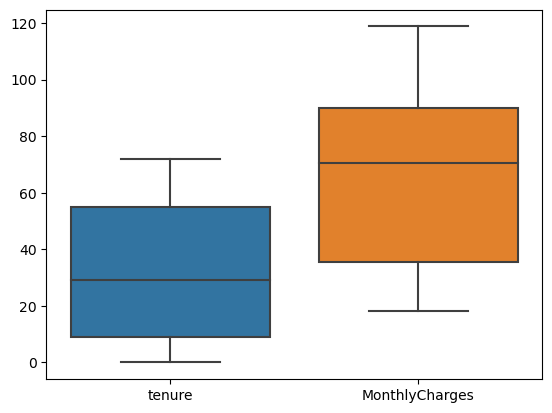

```python
sns.boxplot(sample_df.iloc[:,:2])
```

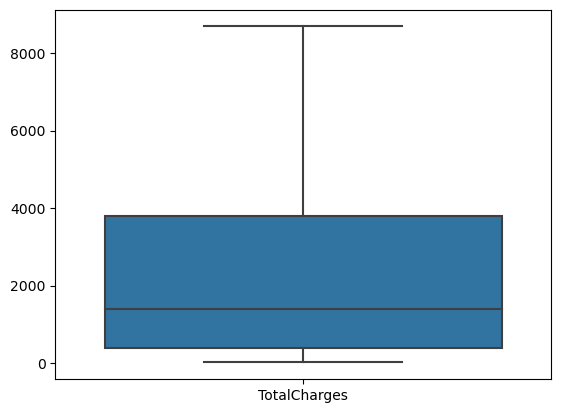

```python
sns.boxplot(sample_df.iloc[:,2:])
```

## > There aren't any outliers visible in the numerical columns

## Exploratory Data Analysis

```
Problem Statement - Given various features about a customer like Gender, SeniorCitizen, Partner, Dependents etc.. , predict if the customer will churn or not.
```

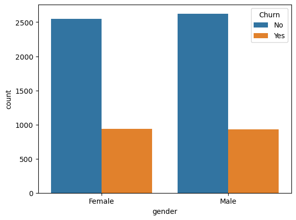

```python
sns.countplot(data=df,x="gender",hue="Churn")
plt.show()
```

```python
df.groupby("gender")["Churn"].value_counts()
```

```
gender  Churn
Female  No       2549
        Yes       939
Male    No       2625
        Yes       930
Name: count, dtype: int64
```

## > From the above we can observe that more females tend to churn compared to men

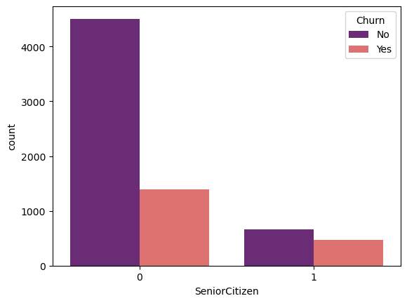

```python
sns.countplot(data=df,x="SeniorCitizen",hue="Churn",palette="magma")
plt.show()
```

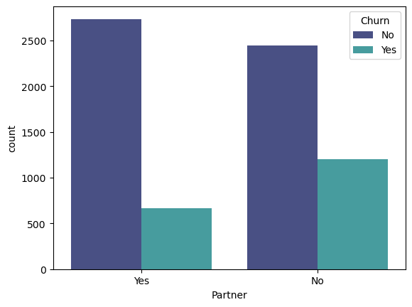

```python
sns.countplot(data=df,x="Partner",hue="Churn",palette="mako")
plt.show()
```

## > From the above we can say that people without a partner tend to churn more than people with a partner

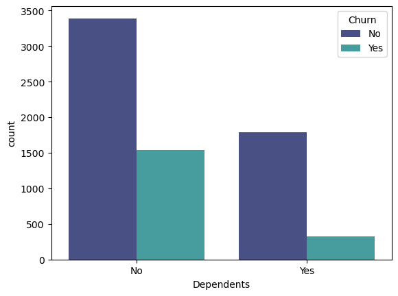

```python
sns.countplot(data=df,x="Dependents",hue="Churn",palette="mako")
plt.show()
```

## > From the above we can say that people with no dependents are most likely to churn compared to people with dependents

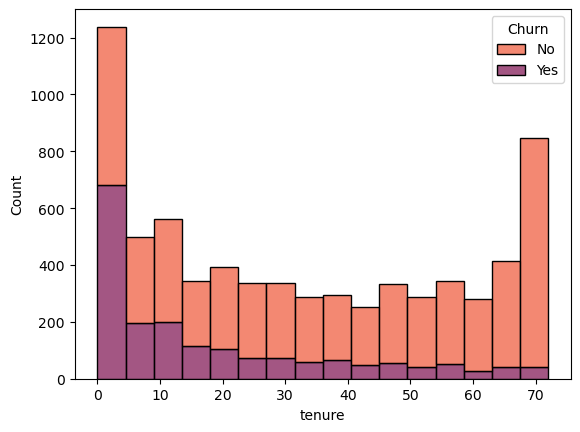

```python
sns.histplot(data=df,x="tenure",multiple="stack",hue=df["Churn"],palette="rocket_r")
```

## > From the above we can say that people tend to churn less the longer they stay in the same place.

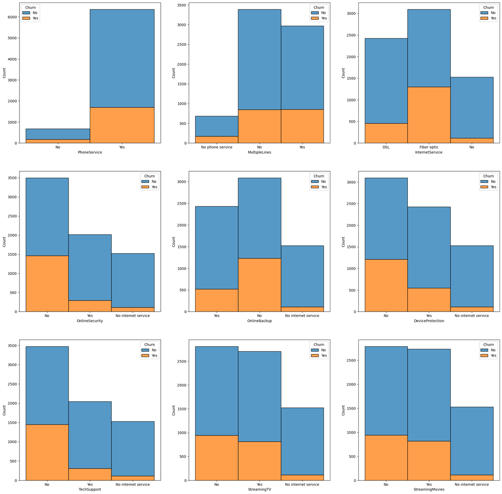

```python
plt.figure(figsize=(24,24))

plt.subplot(3,3,1)
sns.histplot(data=df,x="PhoneService",multiple="stack",hue=df["Churn"])

plt.subplot(3,3,2)
sns.histplot(data=df,x="MultipleLines",multiple="stack",hue=df["Churn"])

plt.subplot(3,3,3)
sns.histplot(data=df,x="InternetService",multiple="stack",hue=df["Churn"])

plt.subplot(3,3,4)
sns.histplot(data=df,x="OnlineSecurity",multiple="stack",hue=df["Churn"])

plt.subplot(3,3,5)
sns.histplot(data=df,x="OnlineBackup",multiple="stack",hue=df["Churn"])

plt.subplot(3,3,6)
sns.histplot(data=df,x="DeviceProtection",multiple="stack",hue=df["Churn"])

plt.subplot(3,3,7)
sns.histplot(data=df,x="TechSupport",multiple="stack",hue=df["Churn"])

plt.subplot(3,3,8)
sns.histplot(data=df,x="StreamingTV",multiple="stack",hue=df["Churn"])

plt.subplot(3,3,9)
sns.histplot(data=df,x="StreamingMovies",multiple="stack",hue=df["Churn"])
plt.show()
```

## > There is a higher churn rate for customers who have the phone service.

## > Customers with internet service fiber optic have a higher churn rate compared with DSL and No. as internet helps with most of the activities.

## > Customers who don’t have access to tech support appear to churn more than those who have the service available.

## > Customers without services like online security, online backup and device protection have a higher churn rate.

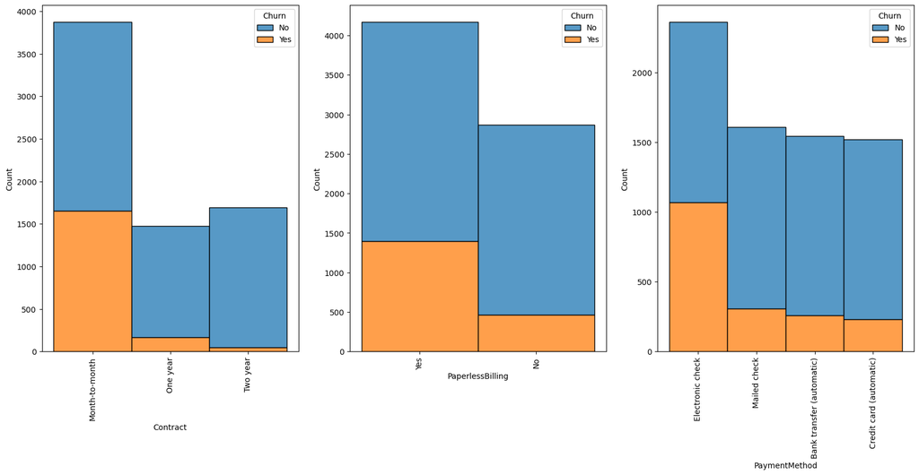

```python
plt.figure(figsize=(20,8))

plt.subplot(1,3,1)
sns.histplot(data=df,x="Contract",multiple="stack",hue=df["Churn"])
plt.xticks(rotation=90)

plt.subplot(1,3,2)
sns.histplot(data=df,x="PaperlessBilling",multiple="stack",hue=df["Churn"])
plt.xticks(rotation=90)

plt.subplot(1,3,3)
sns.histplot(data=df,x="PaymentMethod",multiple="stack",hue=df["Churn"])
plt.xticks(rotation=90)

plt.show()
```

## > people with a month to month contract are most likely churn compared to those with a year or more contract

## > Customers with paperless billing have higher churn rates.

## > Customers who use Electronic check have a higher churn rates in comparision with other payment methods

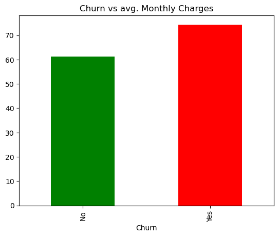

```python
df.groupby("Churn")["MonthlyCharges"].mean().plot.bar(color=["green","red"])
plt.title("Churn vs avg. Monthly Charges")
plt.show()
```

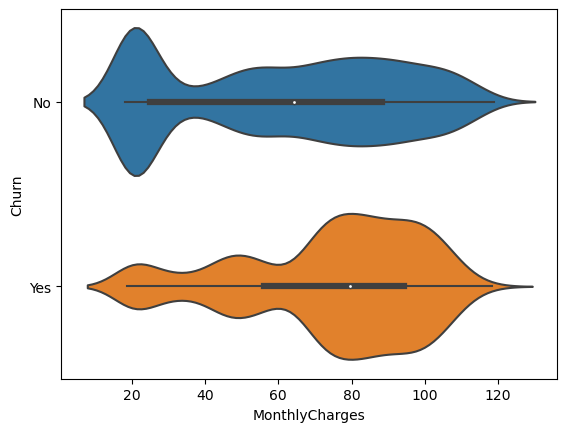

```python
sns.violinplot(data=df,x="MonthlyCharges",y="Churn")
plt.show()
```

## > From the above we can say that people who pay more in monthly charges are likely to churn more.

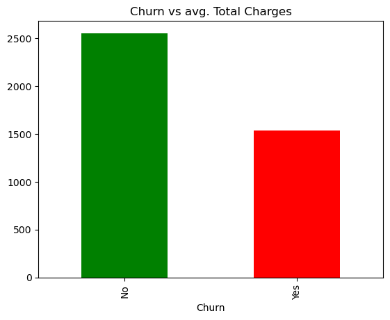

```python
df.groupby("Churn")["TotalCharges"].mean().plot.bar(color=["green","red"])
plt.title("Churn vs avg. Total Charges")
plt.show()
```

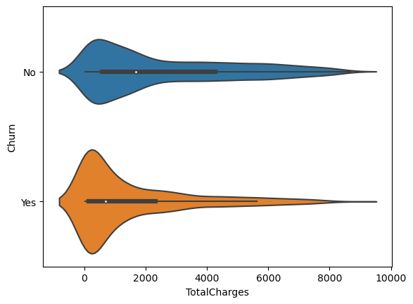

```python
sns.violinplot(data=df,x="TotalCharges",y="Churn")
plt.show()
```

## > From the above we can say that people who pay more in Total charges are likely to churn less as they might have subscribed to multiple services.

## Step - 2: Document the below mentioned points properly:

- Identify the input and output/target variables.
- Identify the type of ML Task.
- Identify the Evaluation Metric.
  - For regression task - Mean Absolute Error
  - For classification task - Accuracy

```python
df.columns
```

```
Index(['customerID', 'gender', 'SeniorCitizen', 'Partner', 'Dependents',
       'tenure', 'PhoneService', 'MultipleLines', 'InternetService',
       'OnlineSecurity', 'OnlineBackup', 'DeviceProtection', 'TechSupport',
       'StreamingTV', 'StreamingMovies', 'Contract', 'PaperlessBilling',
       'PaymentMethod', 'MonthlyCharges', 'TotalCharges', 'Churn'],
      dtype='object')
```

## Step - 3: Split the dataset into Training and Testing (75:25 split)

```python
y = df["Churn"] # output / Target column
x = df[['gender', 'SeniorCitizen', 'Partner', 'Dependents',
       'tenure', 'PhoneService', 'MultipleLines', 'InternetService',
       'OnlineSecurity', 'OnlineBackup', 'DeviceProtection', 'TechSupport',
       'StreamingTV', 'StreamingMovies', 'Contract', 'PaperlessBilling',
       'PaymentMethod', 'MonthlyCharges', 'TotalCharges']] # input
# x = df.iloc[:,1:19]
```

```python
from sklearn.model_selection import train_test_split as split
```

```python
X_train,X_test,Y_train,Y_test = split(x,y,train_size=0.75, random_state = 56)
```

```python
X_train.head()
```

|  | gender | SeniorCitizen | Partner | Dependents | tenure | PhoneService | MultipleLines | InternetService | OnlineSecurity | OnlineBackup | DeviceProtection | TechSupport | StreamingTV | StreamingMovies | Contract | PaperlessBilling | PaymentMethod | MonthlyCharges | TotalCharges |
| --- | --- | --- | --- | --- | --- | --- | --- | --- | --- | --- | --- | --- | --- | --- | --- | --- | --- | --- | --- |
| 2500 | Male | 0 | Yes | Yes | 50 | Yes | No | DSL | Yes | No | No | Yes | Yes | Yes | One year | No | Electronic check | 75.50 | 4025.60 |
| 2456 | Male | 0 | Yes | Yes | 47 | Yes | Yes | No | No internet service | No internet service | No internet service | No internet service | No internet service | No internet service | Two year | No | Mailed check | 24.55 | 1160.45 |
| 1705 | Female | 1 | Yes | No | 55 | Yes | Yes | Fiber optic | No | Yes | Yes | Yes | No | No | Month-to-month | No | Electronic check | 90.45 | 5044.80 |
| 3011 | Female | 0 | Yes | Yes | 9 | Yes | No | No | No internet service | No internet service | No internet service | No internet service | No internet service | No internet service | Two year | No | Mailed check | 19.75 | 210.65 |
| 5444 | Male | 0 | Yes | No | 45 | Yes | Yes | Fiber optic | No | Yes | Yes | No | Yes | Yes | Month-to-month | Yes | Bank transfer (automatic) | 107.75 | 4882.80 |

```python
print(X_train.shape ,Y_train.shape)

print(X_test.shape ,Y_test.shape)
```

```
(5282, 19) (5282,)
(1761, 19) (1761,)
```

## Step - 4: Data preparation on train data:

## Applying Standardization on the numerical columns

```python
X_train_num = X_train.select_dtypes(include=["int64","float64"])
X_train_num
```

|  | SeniorCitizen | tenure | MonthlyCharges | TotalCharges |
| --- | --- | --- | --- | --- |
| 2500 | 0 | 50 | 75.50 | 4025.60 |
| 2456 | 0 | 47 | 24.55 | 1160.45 |
| 1705 | 1 | 55 | 90.45 | 5044.80 |
| 3011 | 0 | 9 | 19.75 | 210.65 |
| 5444 | 0 | 45 | 107.75 | 4882.80 |
| ... | ... | ... | ... | ... |
| 1259 | 1 | 46 | 95.25 | 4424.20 |
| 5538 | 0 | 1 | 81.10 | 81.10 |
| 3264 | 0 | 10 | 91.10 | 964.35 |
| 399 | 0 | 23 | 20.05 | 415.10 |
| 2532 | 1 | 41 | 101.10 | 4016.20 |

5282 rows × 4 columns

```python
from sklearn.preprocessing import StandardScaler

std = StandardScaler()

X_train_num_rescaled = pd.DataFrame(std.fit_transform(X_train_num),
                                   columns=X_train_num.columns,
                                   index = X_train_num.index)

X_train_num_rescaled.head()
```

|  | SeniorCitizen | tenure | MonthlyCharges | TotalCharges |
| --- | --- | --- | --- | --- |
| 2500 | -0.437014 | 0.716720 | 0.358447 | 0.777163 |
| 2456 | -0.437014 | 0.594831 | -1.338011 | -0.492432 |
| 1705 | 2.288259 | 0.919869 | 0.856231 | 1.228787 |
| 3011 | -0.437014 | -0.949099 | -1.497835 | -0.913304 |
| 5444 | -0.437014 | 0.513571 | 1.432261 | 1.157002 |

## Applying OneHotEncoding on Categorical columns

```python
X_train_cat = X_train.select_dtypes(include=["object"])

X_train_cat.head()
```

|  | gender | Partner | Dependents | PhoneService | MultipleLines | InternetService | OnlineSecurity | OnlineBackup | DeviceProtection | TechSupport | StreamingTV | StreamingMovies | Contract | PaperlessBilling | PaymentMethod |
| --- | --- | --- | --- | --- | --- | --- | --- | --- | --- | --- | --- | --- | --- | --- | --- |
| 2500 | Male | Yes | Yes | Yes | No | DSL | Yes | No | No | Yes | Yes | Yes | One year | No | Electronic check |
| 2456 | Male | Yes | Yes | Yes | Yes | No | No internet service | No internet service | No internet service | No internet service | No internet service | No internet service | Two year | No | Mailed check |
| 1705 | Female | Yes | No | Yes | Yes | Fiber optic | No | Yes | Yes | Yes | No | No | Month-to-month | No | Electronic check |
| 3011 | Female | Yes | Yes | Yes | No | No | No internet service | No internet service | No internet service | No internet service | No internet service | No internet service | Two year | No | Mailed check |
| 5444 | Male | Yes | No | Yes | Yes | Fiber optic | No | Yes | Yes | No | Yes | Yes | Month-to-month | Yes | Bank transfer (automatic) |

```python
from sklearn.preprocessing import OneHotEncoder

ohe = OneHotEncoder(drop = "first",sparse_output=False)

X_train_cat_ohe = pd.DataFrame(ohe.fit_transform(X_train_cat),
                               columns = ohe.get_feature_names_out(X_train_cat.columns),
                               index = X_train_cat.index)

X_train_cat_ohe.head()
```

|  | gender_Male | Partner_Yes | Dependents_Yes | PhoneService_Yes | MultipleLines_No phone service | MultipleLines_Yes | InternetService_Fiber optic | InternetService_No | OnlineSecurity_No internet service | OnlineSecurity_Yes | ... | StreamingTV_No internet service | StreamingTV_Yes | StreamingMovies_No internet service | StreamingMovies_Yes | Contract_One year | Contract_Two year | PaperlessBilling_Yes | PaymentMethod_Credit card (automatic) | PaymentMethod_Electronic check | PaymentMethod_Mailed check |
| --- | --- | --- | --- | --- | --- | --- | --- | --- | --- | --- | --- | --- | --- | --- | --- | --- | --- | --- | --- | --- | --- |
| 2500 | 1.0 | 1.0 | 1.0 | 1.0 | 0.0 | 0.0 | 0.0 | 0.0 | 0.0 | 1.0 | ... | 0.0 | 1.0 | 0.0 | 1.0 | 1.0 | 0.0 | 0.0 | 0.0 | 1.0 | 0.0 |
| 2456 | 1.0 | 1.0 | 1.0 | 1.0 | 0.0 | 1.0 | 0.0 | 1.0 | 1.0 | 0.0 | ... | 1.0 | 0.0 | 1.0 | 0.0 | 0.0 | 1.0 | 0.0 | 0.0 | 0.0 | 1.0 |
| 1705 | 0.0 | 1.0 | 0.0 | 1.0 | 0.0 | 1.0 | 1.0 | 0.0 | 0.0 | 0.0 | ... | 0.0 | 0.0 | 0.0 | 0.0 | 0.0 | 0.0 | 0.0 | 0.0 | 1.0 | 0.0 |
| 3011 | 0.0 | 1.0 | 1.0 | 1.0 | 0.0 | 0.0 | 0.0 | 1.0 | 1.0 | 0.0 | ... | 1.0 | 0.0 | 1.0 | 0.0 | 0.0 | 1.0 | 0.0 | 0.0 | 0.0 | 1.0 |
| 5444 | 1.0 | 1.0 | 0.0 | 1.0 | 0.0 | 1.0 | 1.0 | 0.0 | 0.0 | 0.0 | ... | 0.0 | 1.0 | 0.0 | 1.0 | 0.0 | 0.0 | 1.0 | 0.0 | 0.0 | 0.0 |

5 rows × 26 columns

## concatinating the dataframes

```python
x_train_transformed=pd.concat([X_train_cat_ohe,X_train_num_rescaled],axis=1)
x_train_transformed
```

|  | gender_Male | Partner_Yes | Dependents_Yes | PhoneService_Yes | MultipleLines_No phone service | MultipleLines_Yes | InternetService_Fiber optic | InternetService_No | OnlineSecurity_No internet service | OnlineSecurity_Yes | ... | Contract_One year | Contract_Two year | PaperlessBilling_Yes | PaymentMethod_Credit card (automatic) | PaymentMethod_Electronic check | PaymentMethod_Mailed check | SeniorCitizen | tenure | MonthlyCharges | TotalCharges |
| --- | --- | --- | --- | --- | --- | --- | --- | --- | --- | --- | --- | --- | --- | --- | --- | --- | --- | --- | --- | --- | --- |
| 2500 | 1.0 | 1.0 | 1.0 | 1.0 | 0.0 | 0.0 | 0.0 | 0.0 | 0.0 | 1.0 | ... | 1.0 | 0.0 | 0.0 | 0.0 | 1.0 | 0.0 | -0.437014 | 0.716720 | 0.358447 | 0.777163 |
| 2456 | 1.0 | 1.0 | 1.0 | 1.0 | 0.0 | 1.0 | 0.0 | 1.0 | 1.0 | 0.0 | ... | 0.0 | 1.0 | 0.0 | 0.0 | 0.0 | 1.0 | -0.437014 | 0.594831 | -1.338011 | -0.492432 |
| 1705 | 0.0 | 1.0 | 0.0 | 1.0 | 0.0 | 1.0 | 1.0 | 0.0 | 0.0 | 0.0 | ... | 0.0 | 0.0 | 0.0 | 0.0 | 1.0 | 0.0 | 2.288259 | 0.919869 | 0.856231 | 1.228787 |
| 3011 | 0.0 | 1.0 | 1.0 | 1.0 | 0.0 | 0.0 | 0.0 | 1.0 | 1.0 | 0.0 | ... | 0.0 | 1.0 | 0.0 | 0.0 | 0.0 | 1.0 | -0.437014 | -0.949099 | -1.497835 | -0.913304 |
| 5444 | 1.0 | 1.0 | 0.0 | 1.0 | 0.0 | 1.0 | 1.0 | 0.0 | 0.0 | 0.0 | ... | 0.0 | 0.0 | 1.0 | 0.0 | 0.0 | 0.0 | -0.437014 | 0.513571 | 1.432261 | 1.157002 |
| ... | ... | ... | ... | ... | ... | ... | ... | ... | ... | ... | ... | ... | ... | ... | ... | ... | ... | ... | ... | ... | ... |
| 1259 | 0.0 | 0.0 | 0.0 | 1.0 | 0.0 | 0.0 | 1.0 | 0.0 | 0.0 | 0.0 | ... | 1.0 | 0.0 | 0.0 | 1.0 | 0.0 | 0.0 | 2.288259 | 0.554201 | 1.016054 | 0.953789 |
| 5538 | 0.0 | 0.0 | 0.0 | 1.0 | 0.0 | 0.0 | 1.0 | 0.0 | 0.0 | 0.0 | ... | 0.0 | 0.0 | 1.0 | 0.0 | 1.0 | 0.0 | -0.437014 | -1.274136 | 0.544908 | -0.970710 |
| 3264 | 0.0 | 0.0 | 1.0 | 1.0 | 0.0 | 0.0 | 1.0 | 0.0 | 0.0 | 0.0 | ... | 0.0 | 0.0 | 1.0 | 0.0 | 1.0 | 0.0 | -0.437014 | -0.908469 | 0.877873 | -0.579327 |
| 399 | 0.0 | 1.0 | 1.0 | 1.0 | 0.0 | 0.0 | 0.0 | 1.0 | 1.0 | 0.0 | ... | 1.0 | 0.0 | 0.0 | 0.0 | 0.0 | 1.0 | -0.437014 | -0.380283 | -1.487846 | -0.822709 |
| 2532 | 0.0 | 0.0 | 0.0 | 1.0 | 0.0 | 0.0 | 1.0 | 0.0 | 0.0 | 0.0 | ... | 1.0 | 0.0 | 1.0 | 0.0 | 0.0 | 0.0 | 2.288259 | 0.351052 | 1.210839 | 0.772998 |

5282 rows × 30 columns

## Step - 5: Data preparation on test data:

```python
X_test.head()
```

|  | gender | SeniorCitizen | Partner | Dependents | tenure | PhoneService | MultipleLines | InternetService | OnlineSecurity | OnlineBackup | DeviceProtection | TechSupport | StreamingTV | StreamingMovies | Contract | PaperlessBilling | PaymentMethod | MonthlyCharges | TotalCharges |
| --- | --- | --- | --- | --- | --- | --- | --- | --- | --- | --- | --- | --- | --- | --- | --- | --- | --- | --- | --- |
| 6046 | Female | 0 | No | No | 9 | Yes | No | Fiber optic | No | No | Yes | No | No | Yes | Month-to-month | Yes | Credit card (automatic) | 85.3 | 781.40 |
| 6494 | Female | 0 | No | Yes | 26 | No | No phone service | DSL | No | No | Yes | No | No | No | Month-to-month | Yes | Mailed check | 29.8 | 786.50 |
| 2702 | Male | 0 | No | No | 1 | Yes | No | DSL | No | No | No | No | No | No | Month-to-month | No | Electronic check | 44.0 | 44.00 |
| 1532 | Male | 0 | No | No | 14 | Yes | No | No | No internet service | No internet service | No internet service | No internet service | No internet service | No internet service | Month-to-month | No | Credit card (automatic) | 19.6 | 300.40 |
| 3999 | Female | 1 | No | No | 2 | Yes | No | Fiber optic | No | No | No | No | No | No | Month-to-month | Yes | Electronic check | 69.6 | 131.65 |

## Applying Standardization on the numerical columns

```python
X_test_num = X_test.select_dtypes(include=['int64', 'float64'])

X_test_num.head()
```

|  | SeniorCitizen | tenure | MonthlyCharges | TotalCharges |
| --- | --- | --- | --- | --- |
| 6046 | 0 | 9 | 85.3 | 781.40 |
| 6494 | 0 | 26 | 29.8 | 786.50 |
| 2702 | 0 | 1 | 44.0 | 44.00 |
| 1532 | 0 | 14 | 19.6 | 300.40 |
| 3999 | 1 | 2 | 69.6 | 131.65 |

```python
X_test_num_rescaled = pd.DataFrame(std.transform(X_test_num),
                                    columns = X_test_num.columns,
                                    index = X_test_num.index)

X_test_num_rescaled.head()
```

|  | SeniorCitizen | tenure | MonthlyCharges | TotalCharges |
| --- | --- | --- | --- | --- |
| 6046 | -0.437014 | -0.949099 | 0.684754 | -0.660395 |
| 6494 | -0.437014 | -0.258393 | -1.163204 | -0.658135 |
| 2702 | -0.437014 | -1.274136 | -0.690393 | -0.987149 |
| 1532 | -0.437014 | -0.745950 | -1.502829 | -0.873534 |
| 3999 | 2.288259 | -1.233507 | 0.161998 | -0.948310 |

## Applying OneHotEncoding on Categorical columns

```python
X_test_cat = X_test.select_dtypes(include=['object'])

X_test_cat.head()
```

|  | gender | Partner | Dependents | PhoneService | MultipleLines | InternetService | OnlineSecurity | OnlineBackup | DeviceProtection | TechSupport | StreamingTV | StreamingMovies | Contract | PaperlessBilling | PaymentMethod |
| --- | --- | --- | --- | --- | --- | --- | --- | --- | --- | --- | --- | --- | --- | --- | --- |
| 6046 | Female | No | No | Yes | No | Fiber optic | No | No | Yes | No | No | Yes | Month-to-month | Yes | Credit card (automatic) |
| 6494 | Female | No | Yes | No | No phone service | DSL | No | No | Yes | No | No | No | Month-to-month | Yes | Mailed check |
| 2702 | Male | No | No | Yes | No | DSL | No | No | No | No | No | No | Month-to-month | No | Electronic check |
| 1532 | Male | No | No | Yes | No | No | No internet service | No internet service | No internet service | No internet service | No internet service | No internet service | Month-to-month | No | Credit card (automatic) |
| 3999 | Female | No | No | Yes | No | Fiber optic | No | No | No | No | No | No | Month-to-month | Yes | Electronic check |

```python
X_test_cat_ohe = pd.DataFrame(ohe.transform(X_test_cat),
                               columns=ohe.get_feature_names_out(X_test_cat.columns),
                               index = X_test_cat.index)

X_test_cat_ohe.head()
```

|  | gender_Male | Partner_Yes | Dependents_Yes | PhoneService_Yes | MultipleLines_No phone service | MultipleLines_Yes | InternetService_Fiber optic | InternetService_No | OnlineSecurity_No internet service | OnlineSecurity_Yes | ... | StreamingTV_No internet service | StreamingTV_Yes | StreamingMovies_No internet service | StreamingMovies_Yes | Contract_One year | Contract_Two year | PaperlessBilling_Yes | PaymentMethod_Credit card (automatic) | PaymentMethod_Electronic check | PaymentMethod_Mailed check |
| --- | --- | --- | --- | --- | --- | --- | --- | --- | --- | --- | --- | --- | --- | --- | --- | --- | --- | --- | --- | --- | --- |
| 6046 | 0.0 | 0.0 | 0.0 | 1.0 | 0.0 | 0.0 | 1.0 | 0.0 | 0.0 | 0.0 | ... | 0.0 | 0.0 | 0.0 | 1.0 | 0.0 | 0.0 | 1.0 | 1.0 | 0.0 | 0.0 |
| 6494 | 0.0 | 0.0 | 1.0 | 0.0 | 1.0 | 0.0 | 0.0 | 0.0 | 0.0 | 0.0 | ... | 0.0 | 0.0 | 0.0 | 0.0 | 0.0 | 0.0 | 1.0 | 0.0 | 0.0 | 1.0 |
| 2702 | 1.0 | 0.0 | 0.0 | 1.0 | 0.0 | 0.0 | 0.0 | 0.0 | 0.0 | 0.0 | ... | 0.0 | 0.0 | 0.0 | 0.0 | 0.0 | 0.0 | 0.0 | 0.0 | 1.0 | 0.0 |
| 1532 | 1.0 | 0.0 | 0.0 | 1.0 | 0.0 | 0.0 | 0.0 | 1.0 | 1.0 | 0.0 | ... | 1.0 | 0.0 | 1.0 | 0.0 | 0.0 | 0.0 | 0.0 | 1.0 | 0.0 | 0.0 |
| 3999 | 0.0 | 0.0 | 0.0 | 1.0 | 0.0 | 0.0 | 1.0 | 0.0 | 0.0 | 0.0 | ... | 0.0 | 0.0 | 0.0 | 0.0 | 0.0 | 0.0 | 1.0 | 0.0 | 1.0 | 0.0 |

5 rows × 26 columns

## concatinating the dataframes

```python
x_test_transformed=pd.concat([X_test_cat_ohe,X_test_num_rescaled],axis=1)
x_test_transformed
```

|  | gender_Male | Partner_Yes | Dependents_Yes | PhoneService_Yes | MultipleLines_No phone service | MultipleLines_Yes | InternetService_Fiber optic | InternetService_No | OnlineSecurity_No internet service | OnlineSecurity_Yes | ... | Contract_One year | Contract_Two year | PaperlessBilling_Yes | PaymentMethod_Credit card (automatic) | PaymentMethod_Electronic check | PaymentMethod_Mailed check | SeniorCitizen | tenure | MonthlyCharges | TotalCharges |
| --- | --- | --- | --- | --- | --- | --- | --- | --- | --- | --- | --- | --- | --- | --- | --- | --- | --- | --- | --- | --- | --- |
| 6046 | 0.0 | 0.0 | 0.0 | 1.0 | 0.0 | 0.0 | 1.0 | 0.0 | 0.0 | 0.0 | ... | 0.0 | 0.0 | 1.0 | 1.0 | 0.0 | 0.0 | -0.437014 | -0.949099 | 0.684754 | -0.660395 |
| 6494 | 0.0 | 0.0 | 1.0 | 0.0 | 1.0 | 0.0 | 0.0 | 0.0 | 0.0 | 0.0 | ... | 0.0 | 0.0 | 1.0 | 0.0 | 0.0 | 1.0 | -0.437014 | -0.258393 | -1.163204 | -0.658135 |
| 2702 | 1.0 | 0.0 | 0.0 | 1.0 | 0.0 | 0.0 | 0.0 | 0.0 | 0.0 | 0.0 | ... | 0.0 | 0.0 | 0.0 | 0.0 | 1.0 | 0.0 | -0.437014 | -1.274136 | -0.690393 | -0.987149 |
| 1532 | 1.0 | 0.0 | 0.0 | 1.0 | 0.0 | 0.0 | 0.0 | 1.0 | 1.0 | 0.0 | ... | 0.0 | 0.0 | 0.0 | 1.0 | 0.0 | 0.0 | -0.437014 | -0.745950 | -1.502829 | -0.873534 |
| 3999 | 0.0 | 0.0 | 0.0 | 1.0 | 0.0 | 0.0 | 1.0 | 0.0 | 0.0 | 0.0 | ... | 0.0 | 0.0 | 1.0 | 0.0 | 1.0 | 0.0 | 2.288259 | -1.233507 | 0.161998 | -0.948310 |
| ... | ... | ... | ... | ... | ... | ... | ... | ... | ... | ... | ... | ... | ... | ... | ... | ... | ... | ... | ... | ... | ... |
| 3724 | 1.0 | 1.0 | 1.0 | 1.0 | 0.0 | 1.0 | 0.0 | 1.0 | 1.0 | 0.0 | ... | 1.0 | 0.0 | 0.0 | 0.0 | 0.0 | 0.0 | -0.437014 | 1.204277 | -1.329687 | -0.352496 |
| 5540 | 0.0 | 1.0 | 1.0 | 1.0 | 0.0 | 0.0 | 0.0 | 1.0 | 1.0 | 0.0 | ... | 0.0 | 0.0 | 0.0 | 0.0 | 0.0 | 1.0 | -0.437014 | -1.274136 | -1.471197 | -0.997540 |
| 6546 | 1.0 | 0.0 | 0.0 | 1.0 | 0.0 | 0.0 | 0.0 | 0.0 | 0.0 | 1.0 | ... | 0.0 | 0.0 | 1.0 | 0.0 | 1.0 | 0.0 | -0.437014 | -0.339653 | -0.452323 | -0.441363 |
| 5582 | 0.0 | 0.0 | 0.0 | 1.0 | 0.0 | 1.0 | 0.0 | 1.0 | 1.0 | 0.0 | ... | 0.0 | 1.0 | 0.0 | 1.0 | 0.0 | 0.0 | -0.437014 | 0.635461 | -1.356324 | -0.482418 |
| 1621 | 0.0 | 0.0 | 0.0 | 1.0 | 0.0 | 1.0 | 1.0 | 0.0 | 0.0 | 0.0 | ... | 0.0 | 0.0 | 1.0 | 0.0 | 1.0 | 0.0 | -0.437014 | 0.107274 | 0.723045 | 0.335598 |

1761 rows × 30 columns

## Step - 6: Model Training Phase:

- KNN
- Logistic Regression
- Support Vector Machines
- Decision Trees
- Random Forest

```python
from sklearn.linear_model import LogisticRegression
from sklearn.neighbors import KNeighborsClassifier
from sklearn.tree import DecisionTreeClassifier
from sklearn.ensemble import RandomForestClassifier
from sklearn.svm import SVC
from sklearn.metrics import accuracy_score
```

```python
reg_model = [LogisticRegression(),
             KNeighborsClassifier(),
             DecisionTreeClassifier(),
             RandomForestClassifier(),
             SVC()]

algo = []
result = []

for i in reg_model:
    regressor = i
    regressor.fit(x_train_transformed,Y_train)
    y_test_predicted=regressor.predict(x_test_transformed)
    score=accuracy_score(Y_test,y_test_predicted)
    algo.append(str(i))
    result.append(score)
```

```python
print(algo,result)
```

```
['LogisticRegression()', 'KNeighborsClassifier()', 'DecisionTreeClassifier()', 'RandomForestClassifier()', 'SVC()'] [0.8160136286201022, 0.7688813174332766, 0.7336740488358887, 0.7978421351504826, 0.8091993185689949]
```

## Step - 7: Predict and evaluate each model

```python
result_df = pd.DataFrame({"Algorithms":algo
                          ,"Accuracy":result})
result_df
```

|  | Algorithms | Accuracy |
| --- | --- | --- |
| 0 | LogisticRegression() | 0.816014 |
| 1 | KNeighborsClassifier() | 0.768881 |
| 2 | DecisionTreeClassifier() | 0.733674 |
| 3 | RandomForestClassifier() | 0.797842 |
| 4 | SVC() | 0.809199 |

## From the above Accuracy results we can observe that the Logisitic Regression model has the highest accuracy when compared with the other models. We can see that the Logistic Regression model has the accuracy of 0.816. Therefore, we can say that the Logistic Regression appears to be the best model for classification task on our dataset based on the evaluation metrics.